# results_summary

Gabriel Strain

2023-06-21

# H1: Granularity does not predict RT

All analyses were built using R (version 4.3.0. Models were built using the **buildmer** (reference) and **lme4** packages, with plot granularity being set as the predictor for total reaction time. A likelihood ratio test revealed that the model including plot granularity as a predictor failed to explain significantly more variance than a null model ($\chi^2$(1) = 0.74, *p* = .391). This model has a random intercepts and slopes for participants.

# H2: Granularity can predict higher trust ratings

Analyses were built using R (version 4.3.0). Ordinal model was built using the **buildmer** and **ordinal** packages, with plot granularity being set as the predictor for trustworthiness rating. A likelihood ratio test revealed that the model including plot granularity as a predictor explained significantly more variance than a null model ($\chi^2$(1) = 51.65, *p* < .001). Higher granularity plots were rated as being more trustworthy. This model has no random intercepts or slopes.

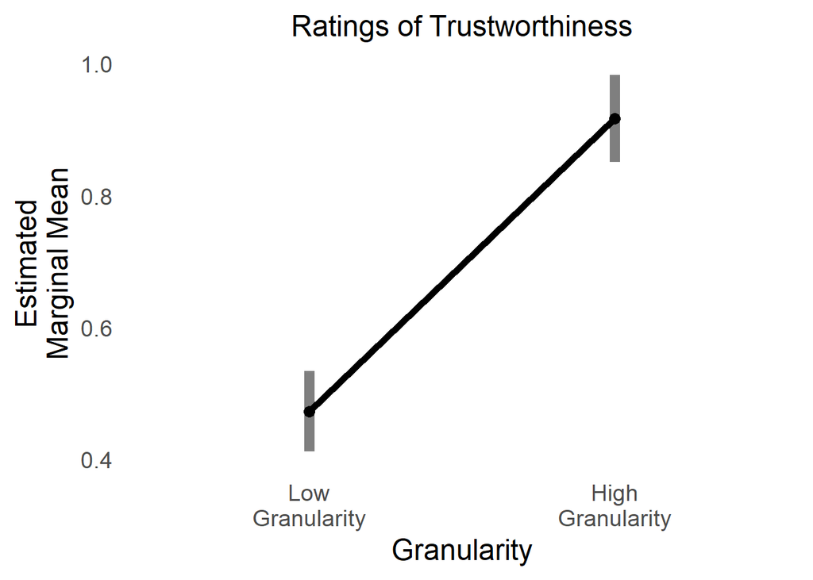

```
FALSE  granularity emmean     SE  df asymp.LCL asymp.UCL
FALSE  LG           0.472 0.0312 Inf     0.411     0.534
FALSE  HG           0.917 0.0335 Inf     0.851     0.983
FALSE
FALSE Confidence level used: 0.95
```

# H3: Weak correlation between granularity and trustworthiness

```r
rcorr(trusty_viz_tidy$trust_slider.response, trusty_viz_tidy$granularity, type = "pearson")
```

```
FALSE      x    y
FALSE x 1.00 0.12
FALSE y 0.12 1.00
FALSE
FALSE n
FALSE       x     y
FALSE x 26854 26854
FALSE y 26854 27180
FALSE
FALSE P
FALSE   x  y
FALSE x     0
FALSE y  0
```

# H4: Granularity and reaction time predict trustworthiness, but there is no interaction.

Analyses were built using R (version 4.3.0. Ordinal model was built using the **buildmer** and **ordinal** packages, with plot granularity and total reaction time being set as the predictors for trustworthiness rating. A likelihood ratio test revealed that the model including plot granularity and total RT as predictors explained significantly more variance than a null model ($\chi^2$(1) = 80.58, *p* < .001). Higher granularity plots were rated as being more trustworthy, and on average peope were faster to respond to plots that they subsequently rated as more trustworthy. This model has no random intercepts or and slopes for items or participants.

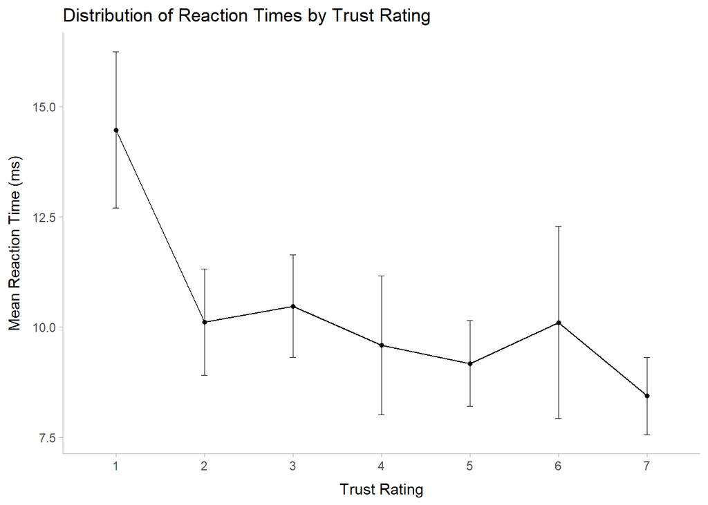

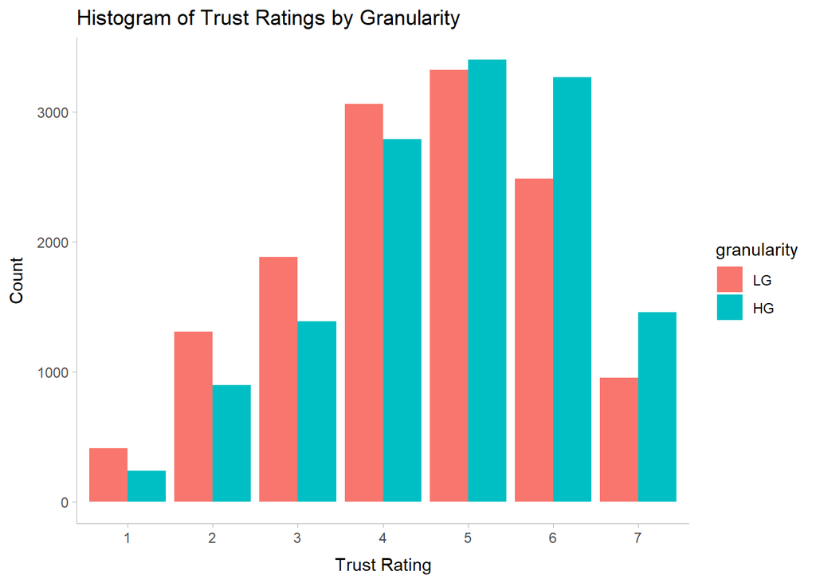

# Graph Literacy

We also generate an additional model to test whether the results we found could be explained by differences in graph literacy. This model is identical to the experimental model, but includes graph literacy as a fixed effect. We found a significant difference between the original model and the one including graph literacy as a fixed effect ($\chi^2$(1) 335.60, *p* < .001). These results suggest that the effect we found may have been driven by differences in graph literacy between participants. A 1 point increase in graph literacy score corresponded to a 0.05 increase in trust score, ($z$ = 18.27, *p* < .001, 95% CI [0.04, 0.05]).

# Dot Pitch

Mean dot pitch was 0.35mm ($SD = 0.07$).

We built a model including dot pitch as a fixed effect. Comparing this to the experimental model revealed a significant effect of dot pitch ($\chi^2$(1) = 5.69, *p* = .017). A 0.1mm increase in dot pitch corresponded to a 0.04 decrease in trust score. ($z$ = -2.39, *p* = .017, 95% CI [-0.67, -0.07]).